# Schissler Final Project

Em Schissler

4/9/2021

## Background

Previous studies have aimed to determine the factors contributing to animal longevity. These factors have included size, metabolism, weight, predation, environment, and diet. However, the definitive factors of longevity remain unknown, and the general pattern of heavier animals living longer has been questioned as the sole determinant of increased lifespan, given the exceptions to this rule within the Animal Kingdom (Ebert, 2008). Additionally, there has been debate over whether animals with a strictly plant-based diet, a strictly meat-based diet, or a combination of both have an increased average lifespan, due to the varying nutritional benefits different foods provide (Wilder et al., 2013).

In this project, we will analyze two datasets. First, I will investigate whether a combination of diet and body mass impacts the average lifespan of mammals using Animal Diversity Web (ADW) data. To further validate the data and results, I will compare the ADW data with the MammalDIET data to determine if the proportion of each diet group is consistent across both datasets, thereby assessing if the ADW sample is representative.

The hypothesis is that increased body mass and a specific diet result in higher average lifespans when combined, as some of the longest-living mammals on the planet have diets consisting of plants (herbivores/omnivores) and possess the largest body mass within the class Mammalia. We will test whether there is a difference in the mean lifespan of mammals across at least one of three diet groups, whether there is an association between mean body mass and mean lifespan of mammals, and whether the effect of diet on mammal longevity depends on the average body mass. Additionally, we will examine the interaction between diet and average body mass.

## Open the Dataset

Down below I imported data from the CSV file FinalMammalData into an R data frame (mammal.data).

```r
mammal.data <- read.csv("FinalMammalData.csv", header=T)
print(mammal.data)
```

```
##                         Species Lifespan    AvgMass       Diet
## 1             Canis lupus dingo    14.80   14500.00 Carnivore
## 2     Crossarchus platycephalus    13.30    1100.00 Carnivore
## 3           Tadarida aegyptiaca    10.00      16.30 Carnivore
## 4           Cystophora cristata    35.00  230000.00 Carnivore
## 5                Mustela itatsi     2.00     300.00 Carnivore
## 6            Mellivora capensis     7.50   10000.00 Carnivore
## 7               Mustela erminea     1.50      70.50 Carnivore
## 8              Myotis lucifugus     6.50       9.50 Carnivore
## 9                Myotis sodalis    20.00       8.00 Carnivore
## 10             Leopardus guigna    11.00    2200.00 Carnivore
## 11                  Felis chaus    13.00   10000.00 Carnivore
## 12        Myrmecobius fasciatus     5.00     526.00 Carnivore
## 13    Lasionycteris noctivagans    12.00      10.00 Carnivore
## 14          Leopardus geoffroyi    14.50    4000.00 Carnivore
```

[output cut: 211 more lines]

## Preliminary Analyses

**Visualizations Scatterplot and Histogram** The data was tested for normality within each treatment group by plotting the original data on a scatter plot and adding histograms of both variables to the graph.

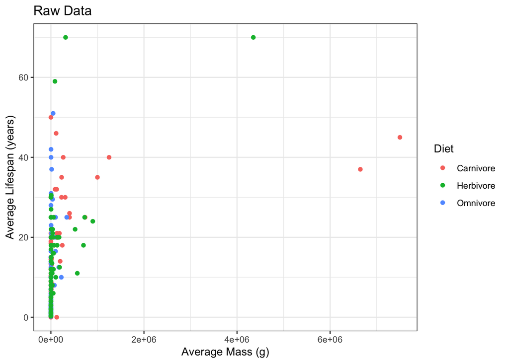

```r
library(ggExtra)
library(ggplot2)
plot1<-ggplot()+
  geom_point(data=mammal.data, aes(x=AvgMass, y=Lifespan, color=Diet))+
  theme_bw()+
  xlab("Average Mass (g)")+
  ylab("Average Lifespan (years)")+
  labs(title=paste("Raw Data"))


print(plot1)
```

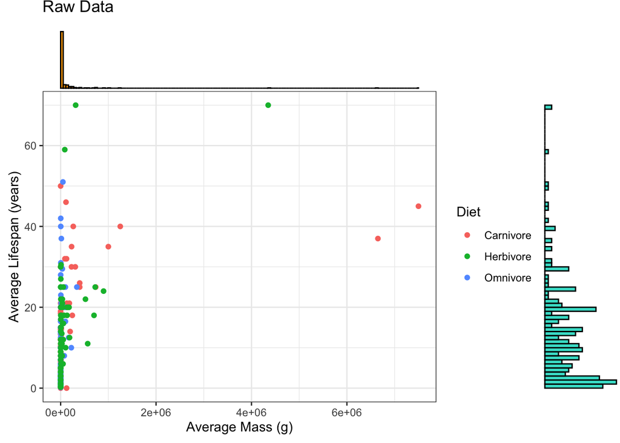

```r
ggMarginal(plot1, type = "histogram",
           xparams = list(binwidth =55000, fill = "orange"),
           yparams = list(binwidth = 1, fill = "turquoise"),
           data=mammal.data)
```

**Transformations of the Data** The initial data showed non-normal distributions, with the average mass data being right-skewed. To address this, a log transformation was applied to the average mass, and a square root transformation was used for the count data of average lifespan. After applying these transformations, the data was plotted again to visually assess whether it appeared more normally distributed within each treatment group.

```r
mammal.data$Mass.tr <- log(mammal.data$AvgMass)
mammal.data$Lifespan.tr <- sqrt(mammal.data$Lifespan + 0.5)
```

## New Scatter plots and Histograms after Transformation

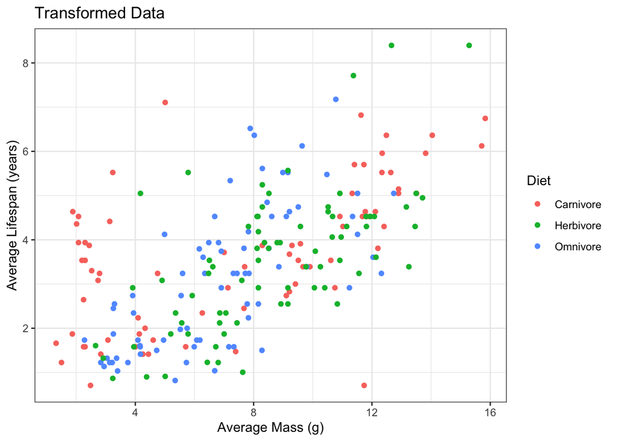

```r
library(ggExtra)
library(ggplot2)
plot2<-ggplot()+
  geom_point(data=mammal.data, aes(x=Mass.tr, y=Lifespan.tr, color=Diet))+
  theme_bw()+
  xlab("Average Mass (g)")+
  ylab("Average Lifespan (years)")+
  labs(title=paste("Transformed Data"))


print(plot2)
```

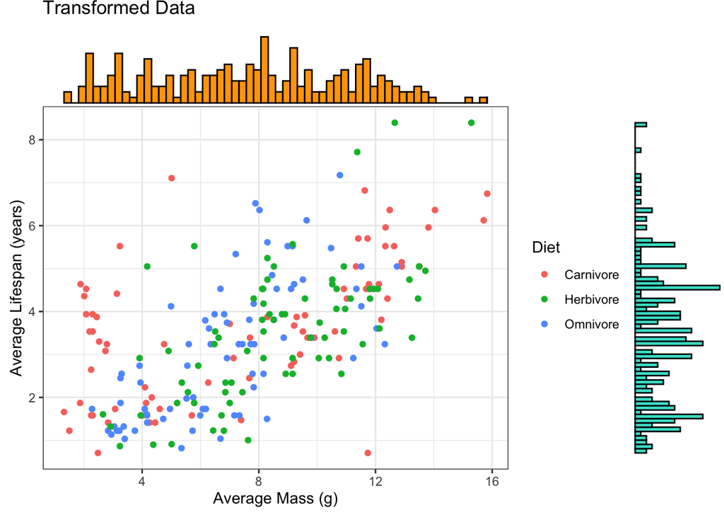

```r
ggMarginal(plot2, type = "histogram",
           xparams = list(binwidth = 0.25, fill = "orange"),
           yparams = list(binwidth = 0.1, fill = "turquoise"),
           data=mammal.data)
```

**Reassigning Variables for Each Diet Category**

Below, each original diet category (Carnivore, Omnivore, and Herbivore) was assgined their own variable so each diet category could be individually tested for normal distributions and equal variance within their data.

```r
carnivore <- subset(mammal.data, Diet == "Carnivore ")
omnivore <- subset(mammal.data, Diet == "Omnivore")
herbivore <- subset(mammal.data, Diet == "Herbivore")
```

**Regression normality test (Sharpio-Wilk)**

Here, I conducted a test for normality on the average lifespan and average body mass variables for each diet dataset.

```r
shapiro.test(carnivore$Mass.tr)
```

```
##
##  Shapiro-Wilk normality test
##
## data:  carnivore$Mass.tr
## W = 0.9047, p-value = 3.373e-05
```

```r
shapiro.test(omnivore$Mass.tr)
```

```
##
##  Shapiro-Wilk normality test
##
## data:  omnivore$Mass.tr
## W = 0.97024, p-value = 0.07439
```

```r
shapiro.test(herbivore$Mass.tr)
```

```
##
##  Shapiro-Wilk normality test
##
## data:  herbivore$Mass.tr
## W = 0.98915, p-value = 0.7762
```

```r
shapiro.test(carnivore$Lifespan.tr)
```

```
##
##  Shapiro-Wilk normality test
##
## data:  carnivore$Lifespan.tr
## W = 0.97472, p-value = 0.1384
```

```r
shapiro.test(omnivore$Lifespan.tr)
```

```
##
##  Shapiro-Wilk normality test
##
## data:  omnivore$Lifespan.tr
## W = 0.94413, p-value = 0.002408
```

```r
shapiro.test(herbivore$Lifespan.tr)
```

```
##
##  Shapiro-Wilk normality test
##
## data:  herbivore$Lifespan.tr
## W = 0.94605, p-value = 0.003045
```

**Levene’s Test**

Down below, I then tested the assumption that the variances are equal within each diet to make sure that variance of mass and average lifespan is not higher in one diet group compared to the others.

```r
#install.packages("lawstat")
library(lawstat)

levene.test(carnivore$Lifespan.tr, carnivore$Mass.tr)
```

```
##
##  Modified robust Brown-Forsythe Levene-type test based on the absolute
##  deviations from the median
##
## data:  carnivore$Lifespan.tr
## Test Statistic = 0.10875, p-value = 1
```

```r
levene.test(omnivore$Lifespan.tr, omnivore$Mass.tr)
```

```
##
##  Modified robust Brown-Forsythe Levene-type test based on the absolute
##  deviations from the median
##
## data:  omnivore$Lifespan.tr
## Test Statistic = 2.3236e+28, p-value < 2.2e-16
```

```r
levene.test(herbivore$Lifespan.tr, herbivore$Mass.tr)
```

```
##
##  Modified robust Brown-Forsythe Levene-type test based on the absolute
##  deviations from the median
##
## data:  herbivore$Lifespan.tr
## Test Statistic = 0.12208, p-value = 1
```

Although the variances were not equal and the data did not meet the criteria for normality, the general linear model test was conducted with approval from my professor. It is important to note that with a large sample size (n=225, with 75 per diet group), it can be challenging to achieve normality.

## General Linear Model Test

Down below, the general linear model test was conducted to determine if the variables are associated with one another and to see if there is an interaction between the two explanatory variables.

```r
glm.results<-lm(Lifespan.tr ~ Diet + Mass.tr +Diet:Mass.tr, data=mammal.data)
summary(glm.results)
```

```
##
## Call:
## lm(formula = Lifespan.tr ~ Diet + Mass.tr + Diet:Mass.tr, data = mammal.data)
##
## Residuals:
##     Min      1Q  Median      3Q     Max
## -3.8782 -0.8198 -0.1932  0.7264  3.9991
##
## Coefficients:
##                       Estimate Std. Error t value Pr(>|t|)
## (Intercept)            2.00599    0.28461   7.048 2.33e-11 ***
## DietHerbivore         -1.52115    0.53287  -2.855 0.004723 **
## DietOmnivore          -1.71394    0.48901  -3.505 0.000554 ***
## Mass.tr                0.21978    0.03270   6.721 1.54e-10 ***
## DietHerbivore:Mass.tr  0.13483    0.05943   2.269 0.024273 *
## DietOmnivore:Mass.tr   0.19139    0.06320   3.028 0.002757 **
## ---
## Signif. codes:  0 '***' 0.001 '**' 0.01 '*' 0.05 '.' 0.1 ' ' 1
##
## Residual standard error: 1.222 on 219 degrees of freedom
## Multiple R-squared:  0.4257, Adjusted R-squared:  0.4126
## F-statistic: 32.46 on 5 and 219 DF,  p-value: < 2.2e-16
```

**Results**

The general linear model results are significant, with a p-value of 2.2e-16. The explanatory variables—average body mass and diet—account for 42.57% of the variability in average lifespan, which is substantial given the complexity of factors influencing longevity.

*Diet (Carnivore, Herbivore, Omnivore) - Categorical Explanatory Variable*

The model rejects the null hypothesis, indicating significant differences in mean lifespan among the diet groups. Specifically, there is a mean difference of -1.52115 between carnivores and herbivores (p-value 0.004723), and -1.71394 between carnivores and omnivores (p-value 0.000554)

## General Linear Model Scatter plot with 2 Explanatory Variables & Regression Line

Down below the results of the general linear model test on were plotted on a scatter plot with regression lines.

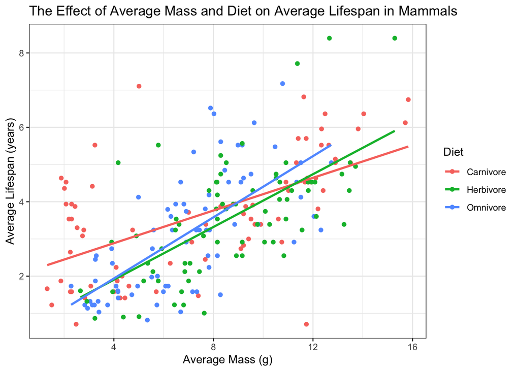

```r
library(ggplot2)
ggplot()+
  geom_point(data=mammal.data, aes(x=Mass.tr, y=Lifespan.tr, color=Diet))+
  geom_smooth(data=mammal.data, aes(x=Mass.tr, y=Lifespan.tr, color=Diet), method="lm", se=F)+
  theme_bw()+
  xlab("Average Mass (g)")+
  ylab("Average Lifespan (years)")+
  labs(title=paste("The Effect of Average Mass and Diet on Average Lifespan in Mammals"))
```

**Figure 1**: Scatter plot measuring average lifespan (years) compared with diet (Carnivore, Herbivore, Omnivore) and average mass (g). Regression lines are shown and color-coded according to diet (n=225, n=75 per diet category). Data provided by Animal Diversity Web.